# The Relationship of Average Income and Voter Preferences in Canada

### Group 47: Hannah Baek, Anna Luo, Farrah Chan, Rachel Yu

## PART I: Introduction

**Relevant background**

Political parties play a large role in promoting participation from citizens in Canadian democracy and representing their needs. The Canadian government is formed by a number of political parties that make up the House of Commons. Federal elections happen every 4 years to determine the distribution of seats for each party, each seat represents their respective constituencies. The proportion of seats to parties determine which party leads the government, as the party with the most seats is able to select the Prime Minister.

Analyses surrounding voting results and behaviour are commonly viewed in comparison to factors such as age, province, and livelihood. In this project we want to explore the relationship between who people voted for in 2015 and their average income level that year. Most of us assume that each party appeals to a specific demographic, and creates legislation that benefits them. Hence, we plan on analyzing how each electoral district voted in comparison to the average income to derive if there is a trend in increase in income and party preference.

Assuming that income distribution is a large factor for voting decisions among citizens when choosing their representatives, we intend to seek evidence of this relationship between income and vote proportions per party.

**Question**

Does a correlation exist between the average income of electoral districts and the voting outcomes for the 5 largest political parties in Canada?

**Methods:**

In this project, we referred to two separate data sets provided by the Canadian government in 2015: the Federal Electoral District Tax Statistics (FEDS) which provides data on the average income levels of the electoral districts, and the 42nd general election: Official Voting Results for the 2015 election results for each district.

We plan to create scatterplots for each political party with income levels on the x-axis and the percentage of votes the party received within the electoral district (%) on the y-axis. Each point will represent an electoral district and we will use the distribution of the points to analyze any patterns in regards to an increase or decrease in income and voter preference. In this analysis we will be removing the variable of time by keeping it as a static analysis of 2015 election results.

Initially we planned to explore this relationship between the Liberal, Conservative, NDP, Green and Bloc Quebecois parties of Canada. After further consideration we decided to remove Bloc Quebecois from our project as it is a geographically-centralized party and the votes received are largely due to Quebec-separatist rhetoric, with income most likely not a driving factor. Due to possible complications such as selection bias and centralization in Quebec, Bloc Quebecois is not an option for most electoral districts.

```r
#Run this cell first
library(tidyverse)
library(testthat)
library(digest)
library(repr)
library(tidymodels)
options(repr.matrix.max.rows = 6)
source('tests.R')
source('cleanup.R')
```

[output not shown]

## Part II: Methods

### Import Income Data

```r
income_data <- read_csv(file = "https://drive.google.com/uc?export=download&id=1zEZSQiKbsvp0ejxJ6gYr0-lkBN3TI3XB") |>
    rename("Electoral_District_ID" = "FED ID", "Federal_Electoral_Districts" = "Federal Electoral Districts") |>
    filter(!is.na(Electoral_District_ID))
income_data
```

A spec_tbl_df: 338 × 5

| Prov/Terr <dbl> | Electoral_District_ID <dbl> | Federal_Electoral_Districts <chr> | Total <dbl> | Total Income <dbl> |
| --- | --- | --- | --- | --- |
| 10 | 10001 | Avalon | 72030 | 3433042000 |
| 10 | 10002 | Bonavista--Burin--Trinity | 64180 | 2487091000 |
| 10 | 10003 | Coast of Bays--Central--Notre Dame | 66890 | 2545490000 |
| ⋮ | ⋮ | ⋮ | ⋮ | ⋮ |
| 60 | 60001 | Yukon | 28010 | 1511702000 |
| 61 | 61001 | Northwest Territories | 31850 | 1962928000 |
| 62 | 62001 | Nunavut | 21050 | 1026526000 |

###### Table 1.0 Income Data

### Import Election Data

```r
#Loads data from the web

election_data <- read_csv("https://drive.google.com/uc?export=download&id=1bn-_WWwhwtmyZwGG_7G9nKCZK2fMFuyq")

#Renames the columns to be descriptive

colnames(election_data) = c("Province", "Electoral_District", "Electoral_District_ID", "Party", "Percentage_of_Votes_Obtained")

#Wrangles and cleans the data

election_data <- filter(election_data, !is.na(Party)) |>
    pivot_wider(names_from = Party, values_from = Percentage_of_Votes_Obtained)
election_data
```

A tibble: 338 × 8

| Province <chr> | Electoral_District <chr> | Electoral_District_ID <dbl> | Liberal <dbl> | NDP <dbl> | Conservative <dbl> | Green Party <dbl> | Bloc Quebecois <dbl> |
| --- | --- | --- | --- | --- | --- | --- | --- |
| Newfoundland and Labrador/Terre-Neuve-et-Labrador | Avalon | 10001 | 55.9 | 14.4 | 11.1 | 0.5 | NA |
| Newfoundland and Labrador/Terre-Neuve-et-Labrador | Bonavista--Burin--Trinity | 10002 | 81.8 | 7.3 | 10.1 | 0.8 | NA |
| Newfoundland and Labrador/Terre-Neuve-et-Labrador | Coast of Bays--Central--Notre Dame | 10003 | 74.8 | 6.1 | 18.3 | 0.8 | NA |
| ⋮ | ⋮ | ⋮ | ⋮ | ⋮ | ⋮ | ⋮ | ⋮ |
| Yukon | Yukon | 60001 | 53.7 | 19.4 | 24.3 | 2.6 | NA |
| Northwest Territories/Territoires du Nord-Ouest | Northwest Territories/Territoires du Nord-Ouest | 61001 | 48.3 | 30.5 | 18.3 | 2.8 | NA |
| Nunavut | Nunavut | 62001 | 47.1 | 26.6 | 24.8 | 1.5 | NA |

###### Table 2.0 Election Data

### Merge Datasets Using Electoral District ID

```r
# Setting up the data frames and summary of the data set for the 4 parties
# all_data <- entire data set
# Conservative_data
# Liberal_data
# NDP_data
# Green_data

all_data <- merge(election_data, income_data, by = "Electoral_District_ID") |>
    rename("Total_Income" = "Total Income",
           "Green" = "Green Party",
           "Bloc" = "Bloc Quebecois",
           "Prov" = "Prov/Terr") |>
    mutate(Average_Income = Total_Income/Total) |>
    select(-Federal_Electoral_Districts, -Province, -Prov)
all_data
```

A data.frame: 338 × 10

| Electoral_District_ID <dbl> | Electoral_District <chr> | Liberal <dbl> | NDP <dbl> | Conservative <dbl> | Green <dbl> | Bloc <dbl> | Total <dbl> | Total_Income <dbl> | Average_Income <dbl> |
| --- | --- | --- | --- | --- | --- | --- | --- | --- | --- |
| 10001 | Avalon | 55.9 | 14.4 | 11.1 | 0.5 | NA | 72030 | 3433042000 | 47661.28 |
| 10002 | Bonavista--Burin--Trinity | 81.8 | 7.3 | 10.1 | 0.8 | NA | 64180 | 2487091000 | 38751.81 |
| 10003 | Coast of Bays--Central--Notre Dame | 74.8 | 6.1 | 18.3 | 0.8 | NA | 66890 | 2545490000 | 38054.87 |
| ⋮ | ⋮ | ⋮ | ⋮ | ⋮ | ⋮ | ⋮ | ⋮ | ⋮ | ⋮ |
| 60001 | Yukon | 53.7 | 19.4 | 24.3 | 2.6 | NA | 28010 | 1511702000 | 53970.08 |
| 61001 | Northwest Territories/Territoires du Nord-Ouest | 48.3 | 30.5 | 18.3 | 2.8 | NA | 31850 | 1962928000 | 61630.39 |
| 62001 | Nunavut | 47.1 | 26.6 | 24.8 | 1.5 | NA | 21050 | 1026526000 | 48766.08 |

###### Table 3.0 Merged Income and Electoral Data

```r
Conservative_data <- select(all_data, Average_Income, Conservative) |>
rename(Percentage_of_Population_Voted = Conservative)
Conservative_data
```

A data.frame: 338 × 2

| Average_Income <dbl> | Percentage_of_Population_Voted <dbl> |
| --- | --- |
| 47661.28 | 11.1 |
| 38751.81 | 10.1 |
| 38054.87 | 18.3 |
| ⋮ | ⋮ |
| 53970.08 | 24.3 |
| 61630.39 | 18.3 |
| 48766.08 | 24.8 |

###### Table 4.0 Conservative Data

```r
Liberal_data <- select(all_data, Average_Income, Liberal) |>
rename(Percentage_of_Population_Voted = Liberal)
Liberal_data
```

A data.frame: 338 × 2

| Average_Income <dbl> | Percentage_of_Population_Voted <dbl> |
| --- | --- |
| 47661.28 | 55.9 |
| 38751.81 | 81.8 |
| 38054.87 | 74.8 |
| ⋮ | ⋮ |
| 53970.08 | 53.7 |
| 61630.39 | 48.3 |
| 48766.08 | 47.1 |

###### Table 5.0 Liberal Data

```r
NDP_data <- select(all_data, Average_Income, NDP)|>
rename(Percentage_of_Population_Voted = NDP)
NDP_data
```

A data.frame: 338 × 2

| Average_Income <dbl> | Percentage_of_Population_Voted <dbl> |
| --- | --- |
| 47661.28 | 14.4 |
| 38751.81 | 7.3 |
| 38054.87 | 6.1 |
| ⋮ | ⋮ |
| 53970.08 | 19.4 |
| 61630.39 | 30.5 |
| 48766.08 | 26.6 |

###### Table 6.0 NDP Data

```r
Green_data <- select(all_data, Average_Income, Green)|>
rename(Percentage_of_Population_Voted = Green)
Green_data
```

A data.frame: 338 × 2

| Average_Income <dbl> | Percentage_of_Population_Voted <dbl> |
| --- | --- |
| 47661.28 | 0.5 |
| 38751.81 | 0.8 |
| 38054.87 | 0.8 |
| ⋮ | ⋮ |
| 53970.08 | 2.6 |
| 61630.39 | 2.8 |
| 48766.08 | 1.5 |

###### Table 7.0 Green Data

### Plot each scatter plot relating to the party

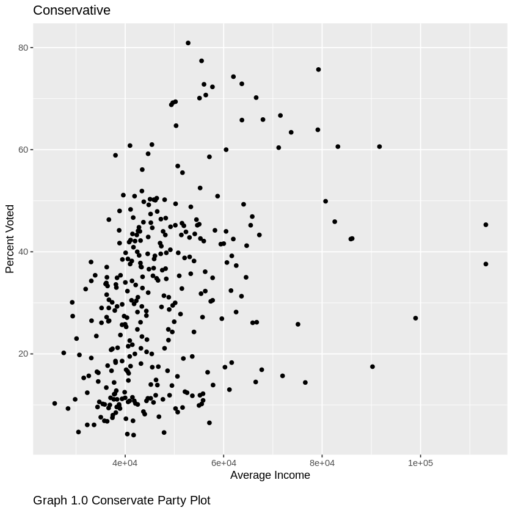

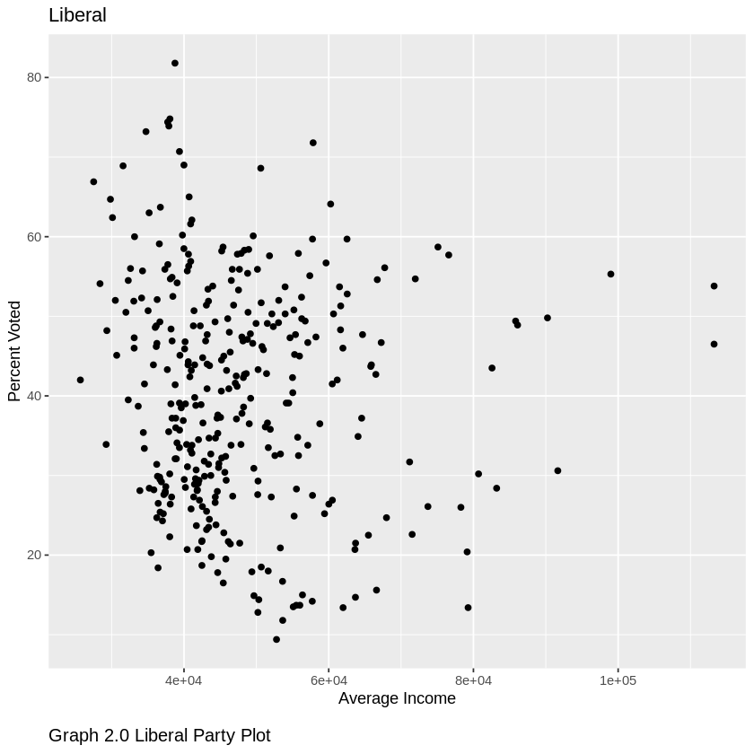

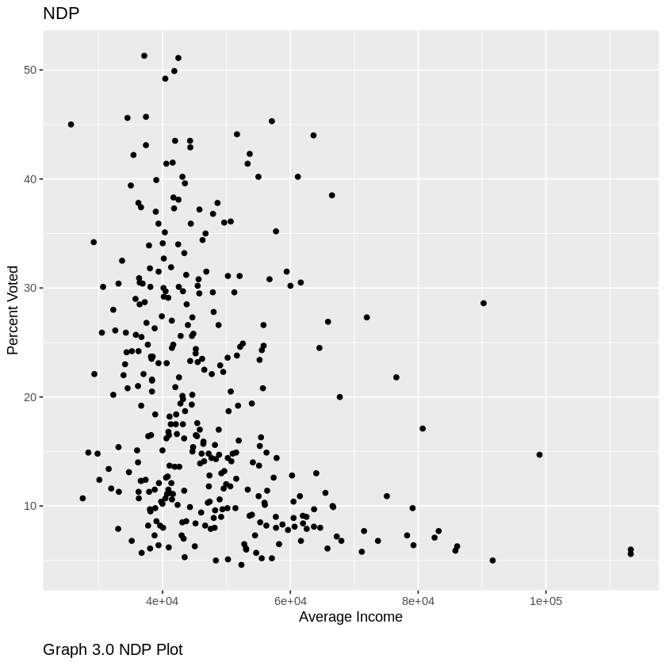

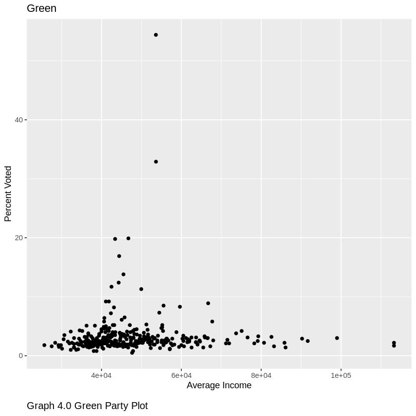

```r
#Before the actual classification, we are visualizing the data as a scatter plot
#where the predictor variable (Average Income) is on the x-axis and the response
#variable (Percentage of Population that voted for the party)is on the y-axis

Conservative_Plot <- ggplot(Conservative_data, aes (x = Average_Income, y = Percentage_of_Population_Voted)) +
                            geom_point() +
                            labs(x = "Average Income", y = "Percent Voted", caption = "Graph 1.0 Conservate Party Plot") +
                            ggtitle("Conservative") +
                            theme(plot.caption=element_text(size=12, hjust=0, margin=margin(15,0,0,0)))
Conservative_Plot

Liberal_Plot <- ggplot(Liberal_data, aes (x = Average_Income, y = Percentage_of_Population_Voted)) +
                            geom_point() +
                            labs(x = "Average Income", y = "Percent Voted", caption = "Graph 2.0 Liberal Party Plot") +
                            ggtitle("Liberal") +
                            theme(plot.caption=element_text(size=12, hjust=0, margin=margin(15,0,0,0)))
Liberal_Plot

NDP_Plot <- ggplot(NDP_data, aes (x = Average_Income, y = Percentage_of_Population_Voted)) +
                            geom_point() +
                            labs(x = "Average Income", y = "Percent Voted", caption = "Graph 3.0 NDP Plot") +
                            ggtitle("NDP") +
                            theme(plot.caption=element_text(size=12, hjust=0, margin=margin(15,0,0,0)))
NDP_Plot

Green_Plot <- ggplot(Green_data, aes (x = Average_Income, y = Percentage_of_Population_Voted)) +
                            geom_point() +
                            labs(x = "Average Income", y = "Percent Voted", caption = "Graph 4.0 Green Party Plot") +
                            ggtitle("Green") +
                            theme(plot.caption=element_text(size=12, hjust=0, margin=margin(15,0,0,0)))
Green_Plot
```

### CONSERVATIVE DATA

```r
#Splitting the data into testing and training data

set.seed(200)

Conservative_split <- initial_split(Conservative_data, prop = 0.75, strata = Percentage_of_Population_Voted)
Conservative_training <- training(Conservative_split)
Conservative_testing <- testing(Conservative_split)

Conservative_testing
```

A data.frame: 86 × 2

|  | Average_Income <dbl> | Percentage_of_Population_Voted <dbl> |
| --- | --- | --- |
| 2 | 38751.81 | 10.1 |
| 6 | 57108.84 | 6.5 |
| 8 | 40706.32 | 16.2 |
| ⋮ | ⋮ | ⋮ |
| 331 | 37409.56 | 21.0 |
| 332 | 75099.80 | 25.8 |
| 333 | 36167.23 | 33.9 |

```r
#Using cross-validation to choose K

Conservative_recipe <- recipe(Percentage_of_Population_Voted ~ Average_Income, data = Conservative_training) |>
  step_scale(all_predictors()) |>
  step_center(all_predictors())

Conservative_spec <- nearest_neighbor(weight_func = "rectangular",
                                      neighbors = tune()) |>
                        set_engine("kknn") |>
                        set_mode("regression")

Conservative_vfold <- vfold_cv(Conservative_training, v = 5, strata = Percentage_of_Population_Voted)

Conservative_wkflw <- workflow() |>
  add_recipe(Conservative_recipe) |>
  add_model(Conservative_spec)

Conservative_wkflw
```

```
══ Workflow ════════════════════════════════════════════════════════════════════
Preprocessor: Recipe
Model: nearest_neighbor()

── Preprocessor ────────────────────────────────────────────────────────────────
2 Recipe Steps

• step_scale()
• step_center()

── Model ───────────────────────────────────────────────────────────────────────
K-Nearest Neighbor Model Specification (regression)

Main Arguments:
  neighbors = tune()
  weight_func = rectangular

Computational engine: kknn
```

```r
#I am running cross-validation for a grid of numbers of neighbors from 1-200
#This will tune the model and give us the RMSPE which we can use to find the
#value of K that minimizes RMSPE. We will use that value of K in our analysis

gridvals <- tibble(neighbors = seq(1,200))

Conservative_results <- Conservative_wkflw |>
  tune_grid(resamples = Conservative_vfold, grid = gridvals) |>
  collect_metrics() |>
  filter(.metric == "rmse")

# show the results
Conservative_results
```

[output not shown]

A tibble: 200 × 7

| neighbors <int> | .metric <chr> | .estimator <chr> | mean <dbl> | n <int> | std_err <dbl> | .config <chr> |
| --- | --- | --- | --- | --- | --- | --- |
| 1 | rmse | standard | 22.96855 | 5 | 0.9905304 | Preprocessor1_Model001 |
| 2 | rmse | standard | 21.00272 | 5 | 0.4763696 | Preprocessor1_Model002 |
| 3 | rmse | standard | 19.65852 | 5 | 0.6583350 | Preprocessor1_Model003 |
| ⋮ | ⋮ | ⋮ | ⋮ | ⋮ | ⋮ | ⋮ |
| 198 | rmse | standard | 17.32874 | 5 | 0.7300267 | Preprocessor1_Model198 |
| 199 | rmse | standard | 16.91528 | 3 | 0.3132629 | Preprocessor1_Model199 |
| 200 | rmse | standard | 17.32165 | 5 | 0.7272020 | Preprocessor1_Model200 |

###### Table 4.1 Conservative Cross Validation Table

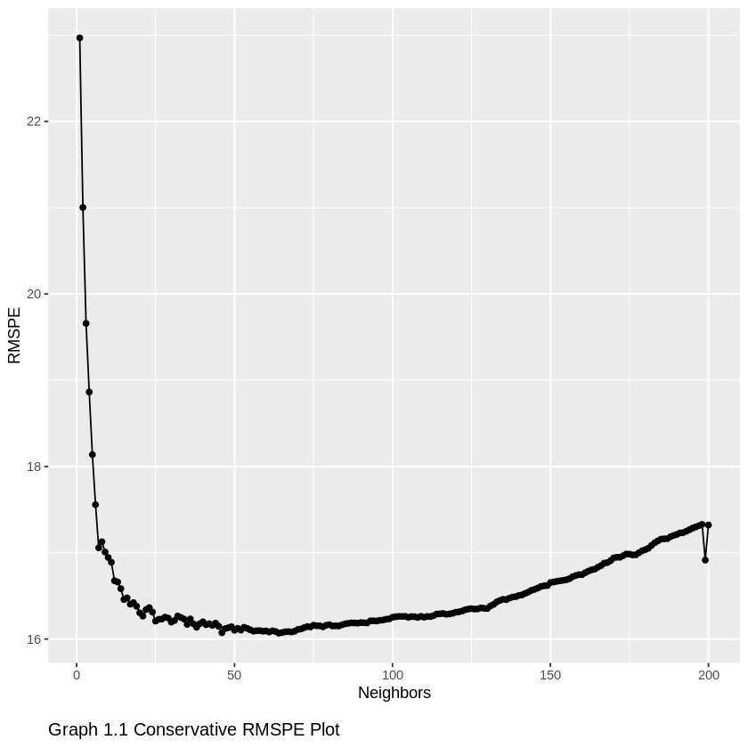

```r
#Here is a vizualization of the RMSPE values for the different K values.
#This shows that the minimum K value is around 60-70. We can find the exact
#K value in the next step.

Conservative_RMSPE_plot <- ggplot(Conservative_results, aes(x = neighbors, y = mean)) +
geom_point() +
geom_line() +
labs(x = "Neighbors", y = "RMSPE", caption = "Graph 1.1 Conservative RMSPE Plot") +
theme(plot.caption=element_text(size=12, hjust=0, margin=margin(15,0,0,0)))

Conservative_RMSPE_plot
```

```r
#This will only show the row of minimum RMSPE which is the K value we want
#to use for the analysis

Conservative_min <- Conservative_results |>
  filter(mean == min(mean))

Conservative_min
```

A tibble: 1 × 7

| neighbors <int> | .metric <chr> | .estimator <chr> | mean <dbl> | n <int> | std_err <dbl> | .config <chr> |
| --- | --- | --- | --- | --- | --- | --- |
| 64 | rmse | standard | 16.06736 | 5 | 0.5068667 | Preprocessor1_Model064 |

###### Table 4.2 Conservative Minimum RMSPE

```r
#In order to use our model on the testing data, we need to retrain
#the KNN regression model on the training data set using the K value
#we found in the earlier step that minimizes RMSPE

kmin <- Conservative_min |> pull(neighbors)

Conservative_spec_test <- nearest_neighbor(weight_func = "rectangular", neighbors = kmin) |>
  set_engine("kknn") |>
  set_mode("regression")

Conservative_fit_test <- workflow() |>
  add_recipe(Conservative_recipe) |>
  add_model(Conservative_spec_test) |>
  fit(data = Conservative_training)

Conservative_summary_test <- Conservative_fit_test |>
  predict(Conservative_testing) |>
  bind_cols(Conservative_testing) |>
  metrics(truth = Percentage_of_Population_Voted, estimate = .pred) |>
  filter(.metric == 'rmse')

Conservative_summary_test
```

A tibble: 1 × 3

| .metric <chr> | .estimator <chr> | .estimate <dbl> |
| --- | --- | --- |
| rmse | standard | 14.30949 |

###### Table 4.3 Conservative RMSE Estimate

```r
#Now we can assess our model and the RMSPE and how well it predicts using
#the testing data we set aside earlier.

Conservative_preds <- tibble(Average_Income = seq(from = 500, to = 125000, by = 10))

Conservative_preds <- Conservative_fit_test |>
  predict(Conservative_preds) |>
  bind_cols(Conservative_preds)

#This is the visualization for the final plot from the Conservative data.
#The blue line is the predicted values of percentage of population
#for the final KNN regression model

Conservative_final <- ggplot(Conservative_training, aes(x = Average_Income, y = Percentage_of_Population_Voted)) +
  geom_point(alpha = 0.4) +
  geom_line(data = Conservative_preds,
            mapping = aes(x = Average_Income, y = .pred),
            color = "blue") +
  xlab("Average Income per person of the District") +
  ylab("Percentage of Population who voted Conservative") +
  ggtitle(paste0("Conservative plot, K = ", kmin)) +
  theme(text = element_text(size = 12))+
  xlim(0,120000)+
  ylim(0,100) +
  labs(caption = "Graph 1.2 Conservative KNN Regresssion Plot") +
  theme(plot.caption=element_text(size=12, hjust=0, margin=margin(15,0,0,0)))

Conservative_final
```

[output not shown]

### LIBERAL

```
══ Workflow ════════════════════════════════════════════════════════════════════
Preprocessor: Recipe
Model: nearest_neighbor()

── Preprocessor ────────────────────────────────────────────────────────────────
2 Recipe Steps

• step_scale()
• step_center()

── Model ───────────────────────────────────────────────────────────────────────
K-Nearest Neighbor Model Specification (regression)

Main Arguments:
  neighbors = tune()
  weight_func = rectangular

Computational engine: kknn
```

[output not shown]

A tibble: 200 × 7

| neighbors <int> | .metric <chr> | .estimator <chr> | mean <dbl> | n <int> | std_err <dbl> | .config <chr> |
| --- | --- | --- | --- | --- | --- | --- |
| 1 | rmse | standard | 17.89318 | 5 | 0.4994864 | Preprocessor1_Model001 |
| 2 | rmse | standard | 16.34126 | 5 | 0.5458242 | Preprocessor1_Model002 |
| 3 | rmse | standard | 15.92175 | 5 | 0.7358229 | Preprocessor1_Model003 |
| ⋮ | ⋮ | ⋮ | ⋮ | ⋮ | ⋮ | ⋮ |
| 198 | rmse | standard | 14.13072 | 5 | 0.3086600 | Preprocessor1_Model198 |
| 199 | rmse | standard | 14.13233 | 5 | 0.3071815 | Preprocessor1_Model199 |
| 200 | rmse | standard | 14.13093 | 5 | 0.3057875 | Preprocessor1_Model200 |

```
[1] "Table 5.1 Liberal Cross Validation Table"
```

A tibble: 1 × 7

| neighbors <int> | .metric <chr> | .estimator <chr> | mean <dbl> | n <int> | std_err <dbl> | .config <chr> |
| --- | --- | --- | --- | --- | --- | --- |
| 43 | rmse | standard | 13.78565 | 5 | 0.3941599 | Preprocessor1_Model043 |

```
[1] "Table 5.2 Liberal Minimum RMSPE"
```

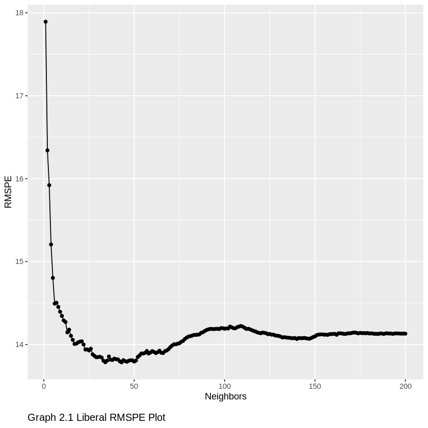

```r
set.seed(200)

#Splitting the data into testing and training data

Liberal_split <- initial_split(Liberal_data, prop = 0.75, strata = Percentage_of_Population_Voted)
Liberal_training <- training(Liberal_split)
Liberal_testing <- testing(Liberal_split)

#Using cross-validation to choose K

Liberal_recipe <- recipe(Percentage_of_Population_Voted ~ Average_Income, data = Liberal_training) |>
  step_scale(all_predictors()) |>
  step_center(all_predictors())

Liberal_spec <- nearest_neighbor(weight_func = "rectangular",
                                      neighbors = tune()) |>
                        set_engine("kknn") |>
                        set_mode("regression")

Liberal_vfold <- vfold_cv(Liberal_training, v = 5, strata = Percentage_of_Population_Voted)

Liberal_wkflw <- workflow() |>
  add_recipe(Liberal_recipe) |>
  add_model(Liberal_spec)

Liberal_wkflw


#I am running cross-validation for a grid of numbers of neighbors from 1-200
#This will tune the model and give us the RMSPE which we can use to find the
#value of K that minimizes RMSPE. We will use that value of K in our analysis

gridvals <- tibble(neighbors = seq(1,200))

Liberal_results <- Liberal_wkflw |>
  tune_grid(resamples = Liberal_vfold, grid = gridvals) |>
  collect_metrics() |>
  filter(.metric == "rmse")

Liberal_results

print("Table 5.1 Liberal Cross Validation Table")

#Here is a vizualization of the RMSPE values for the different K values.
#This shows that the minimum K value is around 40-50. We can find the exact
#K value in the next step.

Liberal_RMSPE_plot <- ggplot(Liberal_results, aes(x = neighbors, y = mean)) +
geom_point() +
geom_line() +
xlab("Neighbors") +
ylab("RMSPE") +
labs(caption = "Graph 2.1 Liberal RMSPE Plot") +
theme(plot.caption=element_text(size=12, hjust=0, margin=margin(15,0,0,0)))

Liberal_RMSPE_plot

#This will only show the row of minimum RMSPE which is the K value we want
#to use for the analysis

Liberal_min <- Liberal_results |>
  filter(mean == min(mean))

Liberal_min

print("Table 5.2 Liberal Minimum RMSPE")
```

The smallest RMSPE occurs when K = 43.

```r
#In order to use our model on the testing data, we need to retrain
#the KNN regression model on the training data set using the K value
#we found in the earlier step that minimizes RMSPE

kmin <- Liberal_min |> pull(neighbors)

Liberal_spec_test <- nearest_neighbor(weight_func = "rectangular", neighbors = kmin) |>
  set_engine("kknn") |>
  set_mode("regression")

Liberal_fit_test <- workflow() |>
  add_recipe(Liberal_recipe) |>
  add_model(Liberal_spec_test) |>
  fit(data = Liberal_training)

Liberal_summary_test <- Liberal_fit_test |>
  predict(Liberal_testing) |>
  bind_cols(Liberal_testing) |>
  metrics(truth = Percentage_of_Population_Voted, estimate = .pred) |>
  filter(.metric == 'rmse')

Liberal_summary_test

print("Table 5.3 Liberal RMSE Estimate")

#Now we can assess our model and the RMSPE and how well it predicts using
#the testing data we set aside earlier.

Liberal_preds <- tibble(Average_Income = seq(from = 500, to = 125000, by = 10))

Liberal_preds <- Liberal_fit_test |>
  predict(Liberal_preds) |>
  bind_cols(Liberal_preds)

#This is the visualization for the final plot from the Liberal data.
#The blue line is the predicted values of percentage of population
#for the final KNN regression model

Liberal_final <- ggplot(Liberal_training, aes(x = Average_Income, y = Percentage_of_Population_Voted)) +
  geom_point(alpha = 0.4) +
  geom_line(data = Liberal_preds,
            mapping = aes(x = Average_Income, y = .pred),
            color = "blue") +
  xlab("Average Income per person of the District") +
  ylab("Percentage of Population who voted Conservative") +
  ggtitle(paste0("Liberal, K = ", kmin)) +
  theme(text = element_text(size = 12))+
xlim(0,120000)+
  ylim(0,100) +
    labs(caption = "2.2 Liberal KNN Regression Plot") +
  theme(plot.caption=element_text(size=12, hjust=0, margin=margin(15,0,0,0)))

Liberal_final
```

[output not shown]

A tibble: 1 × 3

| .metric <chr> | .estimator <chr> | .estimate <dbl> |
| --- | --- | --- |
| rmse | standard | 13.48689 |

```
[1] "Table 5.3 Liberal RMSE Estimate"
```

### NDP

```
══ Workflow ════════════════════════════════════════════════════════════════════
Preprocessor: Recipe
Model: nearest_neighbor()

── Preprocessor ────────────────────────────────────────────────────────────────
2 Recipe Steps

• step_scale()
• step_center()

── Model ───────────────────────────────────────────────────────────────────────
K-Nearest Neighbor Model Specification (regression)

Main Arguments:
  neighbors = tune()
  weight_func = rectangular

Computational engine: kknn
```

[output not shown]

A tibble: 200 × 7

| neighbors <int> | .metric <chr> | .estimator <chr> | mean <dbl> | n <int> | std_err <dbl> | .config <chr> |
| --- | --- | --- | --- | --- | --- | --- |
| 1 | rmse | standard | 15.58772 | 5 | 0.3410399 | Preprocessor1_Model001 |
| 2 | rmse | standard | 13.18092 | 5 | 0.1996476 | Preprocessor1_Model002 |
| 3 | rmse | standard | 12.19950 | 5 | 0.4196959 | Preprocessor1_Model003 |
| ⋮ | ⋮ | ⋮ | ⋮ | ⋮ | ⋮ | ⋮ |
| 198 | rmse | standard | 11.24344 | 5 | 0.3827809 | Preprocessor1_Model198 |
| 199 | rmse | standard | 11.25049 | 5 | 0.3833432 | Preprocessor1_Model199 |
| 200 | rmse | standard | 11.24089 | 5 | 0.3805072 | Preprocessor1_Model200 |

```
[1] "Table 6.1 NDP Cross Validation Table"
```

A tibble: 1 × 7

| neighbors <int> | .metric <chr> | .estimator <chr> | mean <dbl> | n <int> | std_err <dbl> | .config <chr> |
| --- | --- | --- | --- | --- | --- | --- |
| 44 | rmse | standard | 10.89099 | 5 | 0.2973711 | Preprocessor1_Model044 |

```
[1] "Table 6.2 NDP Minimum RMSPE"
```

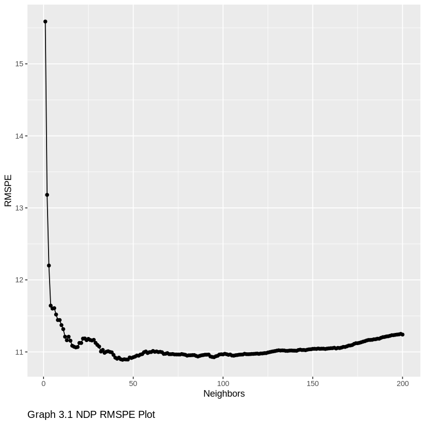

```r
set.seed(200)


#Splitting the data into testing and training data

NDP_split <- initial_split(NDP_data, prop = 0.75, strata = Percentage_of_Population_Voted)
NDP_training <- training(NDP_split)
NDP_testing <- testing(NDP_split)


#Using cross-validation to choose K

NDP_recipe <- recipe(Percentage_of_Population_Voted ~ Average_Income, data = NDP_training) |>
  step_scale(all_predictors()) |>
  step_center(all_predictors())

NDP_spec <- nearest_neighbor(weight_func = "rectangular",
                                      neighbors = tune()) |>
                        set_engine("kknn") |>
                        set_mode("regression")

NDP_vfold <- vfold_cv(NDP_training, v = 5, strata = Percentage_of_Population_Voted)

NDP_wkflw <- workflow() |>
  add_recipe(NDP_recipe) |>
  add_model(NDP_spec)

NDP_wkflw

#I am running cross-validation for a grid of numbers of neighbors from 1-200
#This will tune the model and give us the RMSPE which we can use to find the
#value of K that minimizes RMSPE. We will use that value of K in our analysis

gridvals <- tibble(neighbors = seq(1,200))

NDP_results <- NDP_wkflw |>
  tune_grid(resamples = NDP_vfold, grid = gridvals) |>
  collect_metrics() |>
  filter(.metric == "rmse")

NDP_results

print("Table 6.1 NDP Cross Validation Table")

#Here is a vizualization of the RMSPE values for the different K values.
#This shows that the minimum K value is around 40-50. We can find the exact
#K value in the next step.

NDP_RMSPE_plot <- ggplot(NDP_results, aes(x = neighbors, y = mean)) +
geom_point() +
geom_line() +
xlab("Neighbors") +
ylab("RMSPE") +
labs(caption = "Graph 3.1 NDP RMSPE Plot") +
theme(plot.caption=element_text(size=12, hjust=0, margin=margin(15,0,0,0)))


NDP_RMSPE_plot

#This will only show the row of minimum RMSPE which is the K value we want
#to use for the analysis

NDP_min <- NDP_results |>
  filter(mean == min(mean))

NDP_min

print("Table 6.2 NDP Minimum RMSPE")
```

The smallest RMSPE occurs when K = 44.

```r
#In order to use our model on the testing data, we need to retrain
#the KNN regression model on the training data set using the K value
#we found in the earlier step that minimizes RMSPE

kmin <- NDP_min |> pull(neighbors)

NDP_spec_test <- nearest_neighbor(weight_func = "rectangular", neighbors = kmin) |>
  set_engine("kknn") |>
  set_mode("regression")

NDP_fit_test <- workflow() |>
  add_recipe(NDP_recipe) |>
  add_model(NDP_spec_test) |>
  fit(data = NDP_training)

NDP_summary_test <- NDP_fit_test |>
  predict(NDP_testing) |>
  bind_cols(NDP_testing) |>
  metrics(truth = Percentage_of_Population_Voted, estimate = .pred) |>
  filter(.metric == 'rmse')

NDP_summary_test

print("Table 6.3 NDP RMSE Estimate")

#Now we can assess our model and the RMSPE and how well it predicts using
#the testing data we set aside earlier.

NDP_preds <- tibble(Average_Income = seq(from = 500, to = 125000, by = 10))

NDP_preds <- NDP_fit_test |>
  predict(NDP_preds) |>
  bind_cols(NDP_preds)


#This is the visualization for the final plot from the NDP data.
#The blue line is the predicted values of percentage of population
#for the final KNN regression model

NDP_final <- ggplot(NDP_training, aes(x = Average_Income, y = Percentage_of_Population_Voted)) +
  geom_point(alpha = 0.4) +
  geom_line(data = NDP_preds,
            mapping = aes(x = Average_Income, y = .pred),
            color = "blue") +
  xlab("Average Income per person of the District") +
  ylab("Percentage of Population who voted Conservative") +
  ggtitle(paste0("NDP, K = ", kmin)) +
  theme(text = element_text(size = 12))+
xlim(0,120000)+
  ylim(0,100) +
    labs(caption = "Graph 3.2 NDP KNN Regression Plot") +
theme(plot.caption=element_text(size=12, hjust=0, margin=margin(15,0,0,0)))

NDP_final
```

[output not shown]

A tibble: 1 × 3

| .metric <chr> | .estimator <chr> | .estimate <dbl> |
| --- | --- | --- |
| rmse | standard | 10.66077 |

```
[1] "Table 6.3 NDP RMSE Estimate"
```

### GREEN

```
══ Workflow ════════════════════════════════════════════════════════════════════
Preprocessor: Recipe
Model: nearest_neighbor()

── Preprocessor ────────────────────────────────────────────────────────────────
2 Recipe Steps

• step_scale()
• step_center()

── Model ───────────────────────────────────────────────────────────────────────
K-Nearest Neighbor Model Specification (regression)

Main Arguments:
  neighbors = tune()
  weight_func = rectangular

Computational engine: kknn
```

A tibble: 176 × 7

| neighbors <int> | .metric <chr> | .estimator <chr> | mean <dbl> | n <int> | std_err <dbl> | .config <chr> |
| --- | --- | --- | --- | --- | --- | --- |
| 5 | rmse | standard | 4.304108 | 5 | 0.6580158 | Preprocessor1_Model001 |
| 6 | rmse | standard | 4.250258 | 5 | 0.6835431 | Preprocessor1_Model002 |
| 7 | rmse | standard | 4.203438 | 5 | 0.7498343 | Preprocessor1_Model003 |
| ⋮ | ⋮ | ⋮ | ⋮ | ⋮ | ⋮ | ⋮ |
| 178 | rmse | standard | 3.803811 | 5 | 1.032924 | Preprocessor1_Model174 |
| 179 | rmse | standard | 3.803054 | 5 | 1.033175 | Preprocessor1_Model175 |
| 180 | rmse | standard | 3.802859 | 5 | 1.033735 | Preprocessor1_Model176 |

```
[1] "Table 7.1 Green Cross Validation Table"
```

A tibble: 1 × 7

| neighbors <int> | .metric <chr> | .estimator <chr> | mean <dbl> | n <int> | std_err <dbl> | .config <chr> |
| --- | --- | --- | --- | --- | --- | --- |
| 148 | rmse | standard | 3.779048 | 5 | 1.035155 | Preprocessor1_Model144 |

```
[1] "Table 7.2 Green Minimum RMSPE"
```

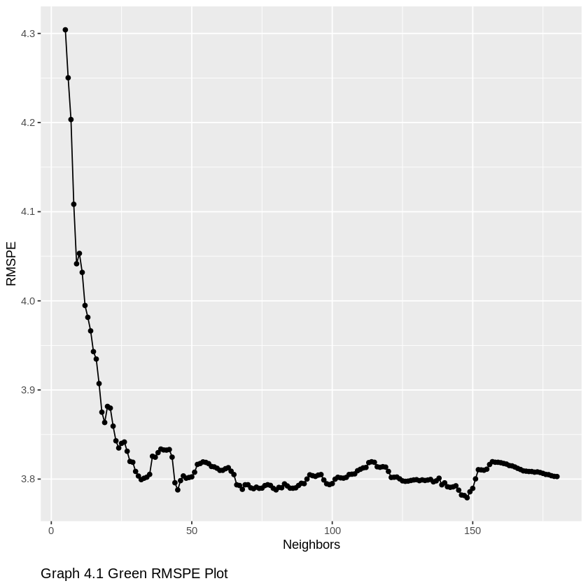

```r
set.seed(200)

#Splitting the data into testing and training data

Green_split <- initial_split(Green_data, prop = 0.75, strata = Percentage_of_Population_Voted)
Green_training <- training(Green_split)
Green_testing <- testing(Green_split)

#Using cross-validation to choose K

Green_recipe <- recipe(Percentage_of_Population_Voted ~ Average_Income, data = Green_training) |>
  step_scale(all_predictors()) |>
  step_center(all_predictors())

Green_spec <- nearest_neighbor(weight_func = "rectangular",
                                      neighbors = tune()) |>
                        set_engine("kknn") |>
                        set_mode("regression")

Green_vfold <- vfold_cv(Green_training, v = 5, strata = Percentage_of_Population_Voted)

Green_wkflw <- workflow() |>
  add_recipe(Green_recipe) |>
  add_model(Green_spec)

Green_wkflw

#I am running cross-validation for a grid of numbers of neighbors from 1-200
#This will tune the model and give us the RMSPE which we can use to find the
#value of K that minimizes RMSPE. We will use that value of K in our analysis

gridvals <- tibble(neighbors = seq(5,180))

Green_results <- Green_wkflw |>
  tune_grid(resamples = Green_vfold, grid = gridvals) |>
  collect_metrics() |>
  filter(.metric == "rmse")

Green_results

print("Table 7.1 Green Cross Validation Table")

#Here is a vizualization of the RMSPE values for the different K values.
#This shows that the minimum K value is around 140-150. We can find the exact
#K value in the next step.

Green_RMSPE_plot <- ggplot(Green_results, aes(x = neighbors, y = mean)) +
geom_point() +
geom_line() +
xlab("Neighbors") +
ylab("RMSPE") +
labs(caption = "Graph 4.1 Green RMSPE Plot") +
theme(plot.caption=element_text(size=12, hjust=0, margin=margin(15,0,0,0)))

Green_RMSPE_plot

#This will only show the row of minimum RMSPE which is the K value we want
#to use for the analysis

Green_min <- Green_results |>
  filter(mean == min(mean))

Green_min

print("Table 7.2 Green Minimum RMSPE")
```

The smallest RMSPE occurs when K = 148.

```r
#In order to use our model on the testing data, we need to retrain
#the KNN regression model on the training data set using the K value
#we found in the earlier step that minimizes RMSPE

kmin <- Green_min |> pull(neighbors)

Green_spec_test <- nearest_neighbor(weight_func = "rectangular", neighbors = kmin) |>
  set_engine("kknn") |>
  set_mode("regression")

Green_fit_test <- workflow() |>
  add_recipe(Green_recipe) |>
  add_model(Green_spec_test) |>
  fit(data = Green_training)

Green_summary_test <- Green_fit_test |>
  predict(Green_testing) |>
  bind_cols(Green_testing) |>
  metrics(truth = Percentage_of_Population_Voted, estimate = .pred) |>
  filter(.metric == 'rmse')

Green_summary_test

print("Table 7.3 Green RMSE Estimate")

#Now we can assess our model and the RMSPE and how well it predicts using
#the testing data we set aside earlier.

Green_preds <- tibble(Average_Income = seq(from = 500, to = 125000, by = 10))

Green_preds <- Green_fit_test |>
  predict(Green_preds) |>
  bind_cols(Green_preds)

#This is the visualization for the final plot from the Green data.
#The blue line is the predicted values of percentage of population
#for the final KNN regression model

Green_final <- ggplot(Green_training, aes(x = Average_Income, y = Percentage_of_Population_Voted)) +
  geom_point(alpha = 0.4) +
  geom_line(data = Green_preds,
            mapping = aes(x = Average_Income, y = .pred),
            color = "blue") +
  xlab("Average Income per person of the District") +
  ylab("Percentage of Population who voted Conservative") +
  ggtitle(paste0("Green Party, K = ", kmin)) +
  theme(text = element_text(size = 12))+
xlim(0,120000)+
  ylim(0,100) +
labs(caption = "Graph 4.2 Green KNN Regression Plot") +
theme(plot.caption=element_text(size=12, hjust=0, margin=margin(15,0,0,0)))

Green_final
```

[output not shown]

A tibble: 1 × 3

| .metric <chr> | .estimator <chr> | .estimate <dbl> |
| --- | --- | --- |
| rmse | standard | 2.451578 |

```
[1] "Table 7.3 Green RMSE Estimate"
```

## PART III: INDIVIDUAL ANALYSIS

```r
Conservative_final
Liberal_final
NDP_final
Green_final
```

[output not shown]

Each scatterplot displays the observations of average income within the range of \$25,000 to \\$112,000 based on the income data collected from the Government of Canada in 2015.

### Conservative Party Analysis

```r
Conservative_final
```

[output not shown]

The increase in voters as the average income range rises may be a result of the Conservative party’s policies on lower tax rates, less government regulation, and reduced government spending. Although lower taxes can also be beneficial to those who earn lower incomes, having less government intervention may lead to more expensive social programs that they may not be able to afford solely based on their salary. Thus, the possibility for higher earning citizens to vote for the Conservative party may be greater than for lower earning citizens.

### Liberal Party Analysis

```r
Liberal_final
```

[output not shown]

A potential reason this trend may be seen can be because the Liberal party is the most central of the top 3 parties. Therefore those who earn a higher wage may value the social views of the Liberal party more than the Conservative party and sacrifice any financial benefits that they may receive from supporting other parties. Additionally, those who may benefit financially from the NDP party may not agree with their social beliefs, and choose to vote for the Liberals who are not as left-leaning.

### New Democratic Party Analysis

```r
NDP_final
```

[output not shown]

A possible explanation for this could be due to the idea that the NDP is more left-leaning, where they believe in a progressive taxing model, and an increase in government intervention. People with a higher income may not feel inclined to vote for the NDP because of these tax policies which target them according to income earned. People with a lower income may feel better represented by the NDP because they may provide more government intervention to make it more equitable in society for them, such as paid social programs, or more healthcare benefits.

### Green Party Analysis

```r
Green_final
```

[output not shown]

This horizontal regression line can be explained by its low popularity, regardless of cultural, social or political beliefs. Since consituency representatives are chosen by a majority vote system, people may not vote for the Green Party due to the lower probability of winning and to avoid casting “wasted votes”. Due to the possibility of casting a wasted vote, many voters may find it more rational to vote for another party they believe have a better chance of winning despite how much they agree with the Green Party.

## Part IV: Discussion + Results

As shown in the scatter plots of the Liberal Party, Conservative Party, New Democratic Party and Green Party one significant observation we made was the drastic differences between each party and their income level to vote relationship. In our Conservative Party graph there is a positive relationship between the increase in average income level and the overall increase in votes. Similarly, the NDP graph shows a relationship between the increase in average income level and an overall decrease in votes. For the Liberal Party there was a more unclear relationship between the average income level and votes as there was a drastic drop and rise in votes between $40,000 and $50,000. Other than that the relationship between the two variables show a steady relationship. Unfortunately for the Green Party graph, due to the lower amount of data our KNN regression line showed no indication of a relationship between income level and voter preference and most votes were concentrated between the incomes of \$30,000 and \\$50,000.

**Expected outcomes and significance:**

*What did you expect to find?*

One of the trends we were expecting was that as the average income rate decreased, voter preference would shift to parties which focus on policies that benefit the low and middle income families. Similarly, as the average income rate increased, voter preference would shift to parties who have less focus on these policies.

For example, the Conservative Party is known to promote the reduction of income tax, which is typically supported by higher income groups. On the other hand, the NDP promises to “[ensure] that large profitable corporations pay a fair share of taxes” and “tax reductions to help the middle class, working families, and the poor” (NDP, 2016) which may be opposed by large business owners and the wealthy.

We also expect to notice that when we compare the parties, the Liberal and Conservative party will have more data samples which may contribute to a more reliable analysis of income to vote trends. With this in mind we expect to see more changes on the KNN nearest neighbour line in a major party such as the Liberal Party when compared to smaller parties such as the Green Party.

*What impact could such findings have?*

Using these findings, we may be able to predict the possible outcomes of an election per electoral district based on its income level. This data could also be used to help parties plan their approach to gaining more seats by targeting the income demographics who do not typically vote for them. We can also identify a trend between income and party preference, allowing us to figure out if specific income demographics believe a party could benefit them more than others. Conducting this research will also be helpful for the government to predict the public reaction to new bills or changes to policies surrounding the topics of income distribution, minimum wage, taxes, immigration and labour.

*What future questions could this lead to?*

In this project we only explored one estimator to voter choice, income, if there is a relationship between income level and voter choice as we predict there may be other predictors that can explain the deciding factors for popular political parties. This could lead to questions about which parties receive the most support from high and low earning households. Do the rich prefer certain parties because their legislation focuses on protecting their wealth or because these parties represent their moral and ethical views?

Some ways we can expand or add to this research is if we look into social inequalities that may affect voter participation. Further research on gender differences, immigration status, and socioeconomic inequalities may help with predictions and solutions. If we were to add onto this project we would focus on the effect of gender inequity and how the wage gap affects the decision to support certain political parties.

### Concluding Remarks

In summary, there appears to be a direct relationship between the average income levels of constituencies and their voting preferences. This supports our prediction that as the income level rises or falls, certain parties such as the Conservative Party and New Democratic Party gain popularity. We recognize that the data we used is within a limited scope of the 2015 federal election and to expand on this research in the future we must also consider the data from all previous and future federal elections. Another way we can expand on this research is to consider other socioeconomic and identity factors which will help reduce the residual error.

### Works Cited

Polacko, M. (2020). Party Positions, Income Inequality, and Voter Turnout in Canada, 1984-2015. American Behavioral Scientist, 64(9), 1324–1347. https://doi.org/10.1177/0002764220941238

Hersh, E. & Nall, C (2016). The Primacy of Race in the Geography of Income-Based Voting: New Evidence from Public Voting Records. American Journal of Political Science Vol. 60, No. 2. 289-303. https://www.jstor.org/stable/24877622

Government of Canada (2015). Federal Electoral District Tax Statistics (FEDS) (tax year 2015). Open Government Portal. https://open.canada.ca/data/en/dataset/90fed920-c32d-4a41-8f26-53392eb78671

Government of Canada (2015). 42nd general election: Official Voting Results - Table 12: List of candidates by electoral district and individual results. Open Government Portal. https://open.canada.ca/data/en/dataset/775f3136-1aa3-4854-a51e-1a2dab362525/resource/14b9eb9e-495e-452a-8ff1-b0f9670a504f

Policy declaration - Conservative Party of Canada. Conservative Party of Canada. (2018). Retrieved from https://cpcassets.conservative.ca/wp-content/uploads/2020/10/15090948/9f7f204744e7480.pdf

Policy of the New Democratic Party of Canada. New Democratic Party. (2016). Retrievedfrom https://xfer.ndp.ca/2017/Documents/2016_POLICY-EN.pdf